# BIOSTAT702 R Tutorial 3:

Simple Linear Regression

Marissa Ashner, PhD

Last Updated: 2024-08-12

This tutorial will follow closely with parts of Chapters 4 and 5 in the [textbook](https://bookdown.org/rwnahhas/RMPH/datasumm.html).

# Packages

The following code loads the packages you need for the tutorial.

```r
## NOTE: If you do not have a package installed, you must install it first
# For example, you can run the following code if you don't have the gtsummary package:
# install.packages("gtsummary")


# for navigating within the R project
library(here)

# for data wrangling
library(tidyverse)

# for nice-looking tables
library(gtsummary)

# for splines
library(Hmisc)

# for checking assumptions / diagnostics
library(car)
library(olsrr)
```

# Resources

Below is a list of resources that may be helpful or provide more information on this topic.

- [Applet for Least Squares Illustration](https://www.rossmanchance.com/applets/2021/regshuffle/regshuffle.htm)
- [Guide to Regression Diagnostics with R](https://sscc.wisc.edu/sscc/pubs/RegDiag-R/index.html)

# Load Data

There will be two different datasets used for this tutorial. Both are loaded here.

```r
# Load Data
# will be called "nhanes_adult_exam_sub" in your environment
load(here("data/nhanes1718_adult_fast_sub_rmph.Rdata"))

# rename dataset for convenience
nhanesf <- nhanes_adult_fast_sub

# will be called "unhdd" in your environment
load(here("data/unhdd2020.rmph.rData"))
```

# Visualize the Data

From the NHANES dataset, we will investigate how the mean fasting glucose varies with waist circumference (a continuous predictor). The first thing to do is visualize the data.

## Visualizing the Distribution of the Outcome

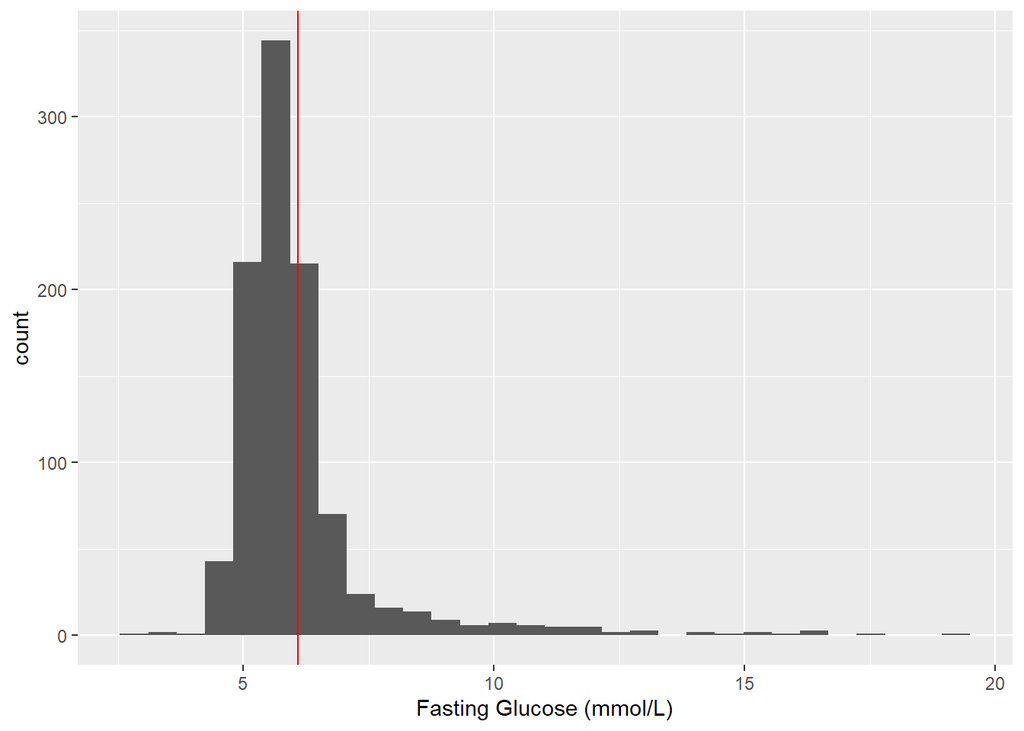

```r
ggplot(data = nhanesf) +
  geom_histogram(aes(LBDGLUSI)) +
  labs(x = "Fasting Glucose (mmol/L)") +
  geom_vline(xintercept = mean(nhanesf$LBDGLUSI), color = "red")
```

## Visualizing the Distribution of the Predictor

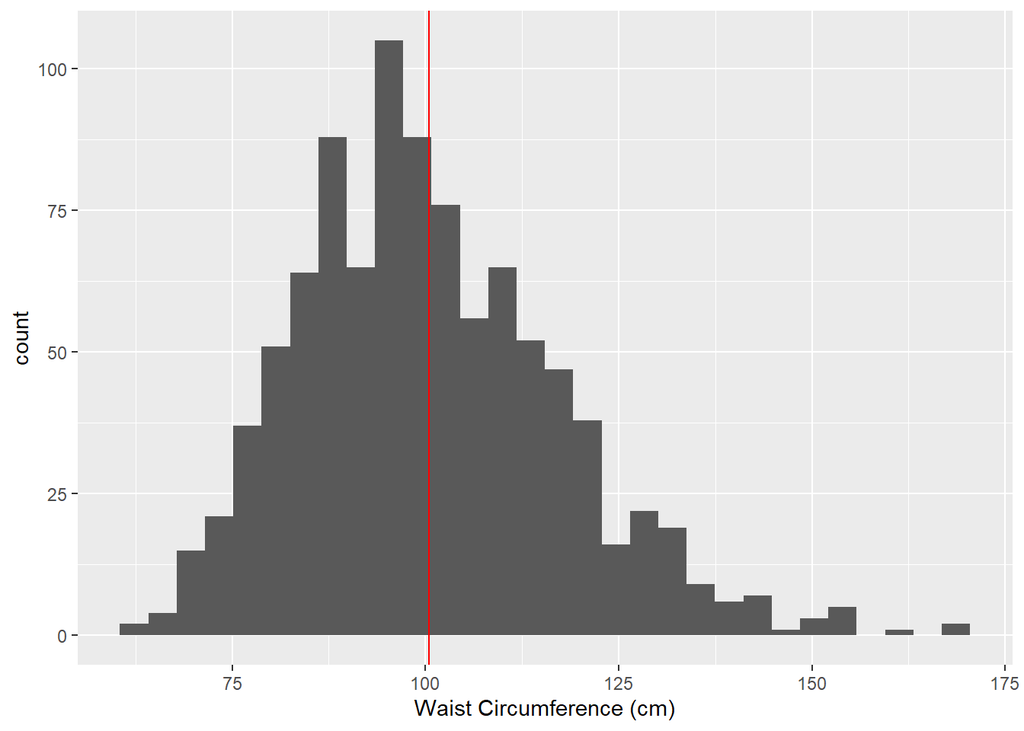

```r
ggplot(data = nhanesf) +
  geom_histogram(aes(BMXWAIST)) +
  labs(x = "Waist Circumference (cm)") +
  geom_vline(xintercept = mean(nhanesf$BMXWAIST, na.rm = TRUE),
             color = "red")
```

## Visualizing the Relationship between the Predictor and Outcome

We can visualize the relationship between the two variables using a scatterplot. We can then append the best fit line to this scatterplot using the `lm` method. We will cover the details of this method in the next section.

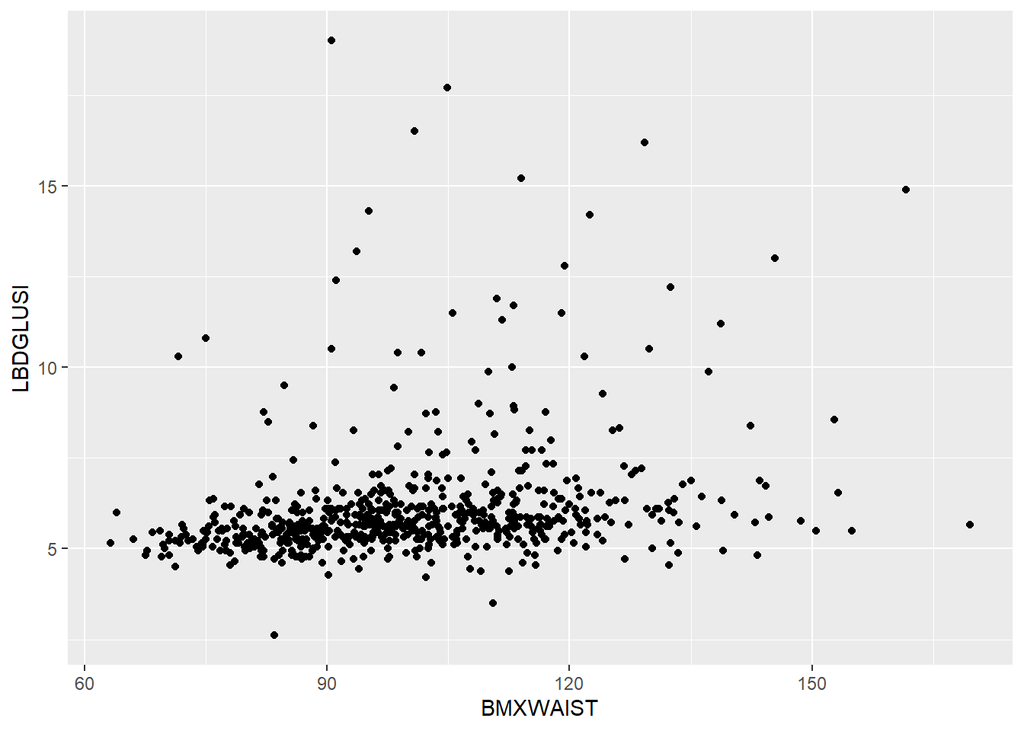

```r
# Plot the scatterplot
ggplot(data = nhanesf) + geom_point(aes(BMXWAIST, LBDGLUSI))
```

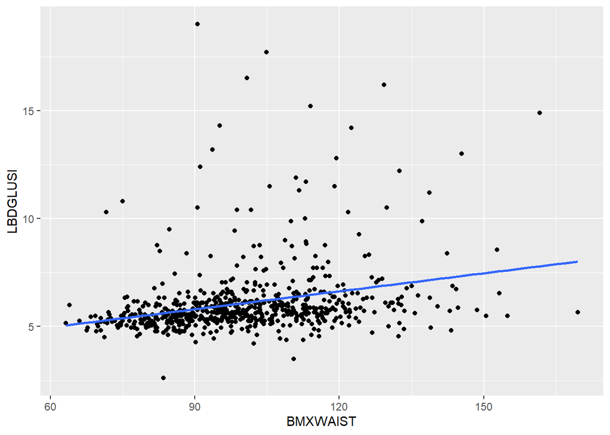

```r
# Plot the scatterplot with an appended best fit line
ggplot(data = nhanesf, aes(BMXWAIST, LBDGLUSI)) + geom_point() + geom_smooth(method = lm, se = FALSE)
```

### Fitting smooth curves to the scatterplot

Rather than just appending the best fit line, we can also append smoothers such as a LOESS curve or a spline. Here, we will show an example using a LOESS curve and a restricted cubic spline (RCS). Note there are other types of splines available as well. The RCS function `rcspline.eval()` is in the `Hmisc` package.

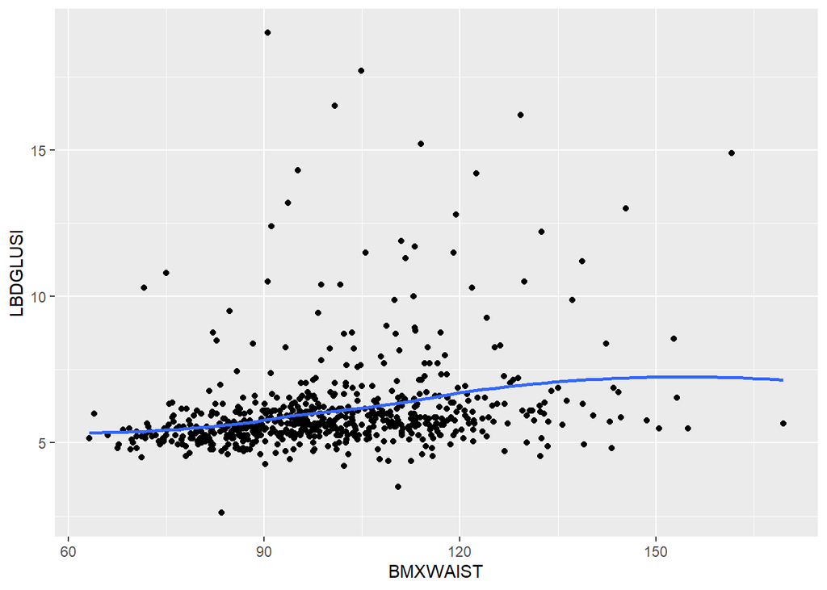

```r
# plot scatterplot with appended LOESS curve
ggplot(data = nhanesf, aes(BMXWAIST, LBDGLUSI)) + geom_point() +
  geom_smooth(method = "loess", se = FALSE)
```

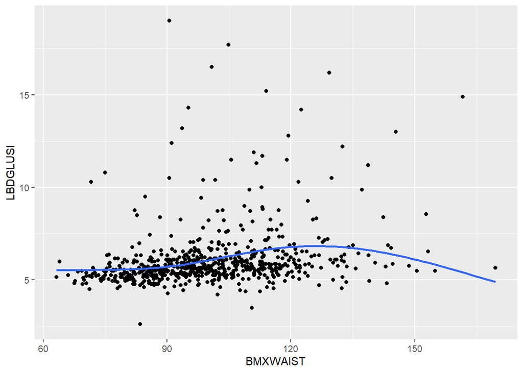

```r
# plot scatterplot with appended RCS
ggplot(data = nhanesf, aes(BMXWAIST, LBDGLUSI)) + geom_point() +
  geom_smooth(method = "lm",
              # look at the arguments for ?rcspline.eval to see how you can change the number and location of knots
              formula = y ~ rcspline.eval(x),
              se = FALSE)
```

# Fitting the Linear Model

Aside from using the `lm` method in the `geom_smooth` function to append the best fit line to a scatterplot, we can run the `lm()` function independently to fit a simple linear regression model to the data. The output can be explored by using the `summary()` function. This function outputs the following information:

- The function call
- Descriptive Statistics regarding the residuals
- The coefficients
  - parameter estimates
  - standard errors
  - t-test statistic
  - p-value for the Wald-type t-test
- The residual standard error (i.e., the estimate of $\sigma$, the standard deviation of the model error term)
- The residual standard error degrees of freedom (sample size - # of regression parameters)
- Number of observations excluded (R automatically deletes any observations with missing data)
- Multiple $R^2$ (square of the pearson correlation coefficient)
- Adjusted $R^2$ (penalizes the correlation based on how many predictors are in the model)
- Global F Test

```r
# fit the model
fit1 <- lm(LBDGLUSI ~ BMXWAIST, data = nhanesf)

# output the results
summary(fit1)
```

```
##
## Call:
## lm(formula = LBDGLUSI ~ BMXWAIST, data = nhanesf)
##
## Residuals:
##     Min      1Q  Median      3Q     Max
## -3.0122 -0.6853 -0.2797  0.1682 13.1835
##
## Coefficients:
##             Estimate Std. Error t value Pr(>|t|)
## (Intercept) 3.304091   0.295020  11.200   <2e-16 ***
## BMXWAIST    0.027761   0.002895   9.588   <2e-16 ***
## ---
## Signif. codes:  0 '***' 0.001 '**' 0.01 '*' 0.05 '.' 0.1 ' ' 1
##
## Residual standard error: 1.523 on 963 degrees of freedom
##   (35 observations deleted due to missingness)
## Multiple R-squared:  0.08714,    Adjusted R-squared:  0.0862
## F-statistic: 91.93 on 1 and 963 DF,  p-value: < 2.2e-16
```

You can also access specific elements of the linear model fit summary using the `$`. A few examples are below.

```r
summary(fit1)$coef
```

```
##               Estimate  Std. Error   t value     Pr(>|t|)
## (Intercept) 3.30409136 0.295020024 11.199550 1.872651e-27
## BMXWAIST    0.02776135 0.002895394  9.588108 7.392885e-21
```

```r
summary(fit1)$coef["BMXWAIST", "Pr(>|t|)"]
```

```
## [1] 7.392885e-21
```

The `confint()` function will return confidence intervals for all coefficients in your model.

```r
confint(fit1)
```

```
##                  2.5 %     97.5 %
## (Intercept) 2.72513508 3.88304764
## BMXWAIST    0.02207934 0.03344336
```

## Nice-Looking Summary Table

The `gtsummary` package can be used to create a more aesthetically pleasing table. You can then export this to a word document.

```r
fit1_table <- fit1 %>%
  tbl_regression(intercept = T,
                 estimate_fun = function(x) style_sigfig(x, digits = 4),
                 pvalue_fun   = function(x) style_pvalue(x, digits = 3),
                 label        = list(BMXWAIST ~ "Waist circumference (cm)")) %>%
  modify_caption("Regression of fasting glucose (mmol/L) on waist circumference")
fit1_table
```

Regression of fasting glucose (mmol/L) on waist circumference

| **Characteristic** | **Beta** | **95% CI**<sup>1</sup> | **p-value** |
| --- | --- | --- | --- |
| (Intercept) | 3.304 | 2.725, 3.883 | <0.001 |
| Waist circumference (cm) | 0.0278 | 0.0221, 0.0334 | <0.001 |

<sup>1</sup> CI = Confidence Interval

```r
fit1_table %>%
  as_flex_table() %>%
  flextable::save_as_docx(path = here("03-SimpleLinearRegression",
                           "03-fit1table.docx"))
```

## Centering and Scaling a Continuous Predictor

Sometimes it is of interest to center and/or scale the continuous predictor. This is easy to do in R.

### Centering Only

To only center the continuous predictor, you can create a centered variable “by hand” or use the `scale()` function. We do both below and see the results are equivalent.

```r
nhanesf$BMXWAISTc = nhanesf$BMXWAIST - mean(nhanesf$BMXWAIST, na.rm = TRUE)

nhanesf$BMXWAISTc2 = scale(nhanesf$BMXWAIST, scale = FALSE)[,1]

identical(nhanesf$BMXWAISTc, nhanesf$BMXWAISTc2)
```

```
## [1] TRUE
```

### Centering and Scaling

The default for the `scale()` function is to both center and scale the variable.

```r
nhanesf$BMXWAISTs = scale(nhanesf$BMXWAIST)[,1]
```

### How this changes the regression coefficients

We can compare the coefficients from the original fit, the centered fit, and the centered and scaled fit. Centering the predictor only changes the intercept estimate. Scaling the predictor changes the estimate of the predictor, but not the test statistic or p-value.

```r
fit1c = lm(LBDGLUSI ~ BMXWAISTc, data = nhanesf)

fit1s = lm(LBDGLUSI ~ BMXWAISTs, data = nhanesf)

summary(fit1)$coef
```

```
##               Estimate  Std. Error   t value     Pr(>|t|)
## (Intercept) 3.30409136 0.295020024 11.199550 1.872651e-27
## BMXWAIST    0.02776135 0.002895394  9.588108 7.392885e-21
```

```r
summary(fit1c)$coef
```

```
##               Estimate  Std. Error    t value     Pr(>|t|)
## (Intercept) 6.09341969 0.049041210 124.251007 0.000000e+00
## BMXWAISTc   0.02776135 0.002895394   9.588108 7.392885e-21
```

```r
summary(fit1s)$coef
```

```
##              Estimate Std. Error    t value     Pr(>|t|)
## (Intercept) 6.0934197 0.04904121 124.251007 0.000000e+00
## BMXWAISTs   0.4704562 0.04906664   9.588108 7.392885e-21
```

# Predictions from the Model

You can use the `predict()` function to output the predicted outcome with a certain level of the predictor. You can include a confidence interval, prediction interval, or neither. Prediction intervals are wider than confidence intervals because they account for the additional uncertainty surrounding an individual prediction, where confidence intervals describe the confidence around the mean.

```r
predict(fit1,
        newdata = data.frame(BMXWAIST = 100),
        interval = "confidence")
```

```
##        fit      lwr      upr
## 1 6.080227 5.983949 6.176504
```

```r
predict(fit1,
        newdata = data.frame(BMXWAIST = 100),
        interval = "prediction")
```

```
##        fit      lwr      upr
## 1 6.080227 3.089035 9.071418
```

We can very easily add the confidence intervals to our scatterplot as shown below.

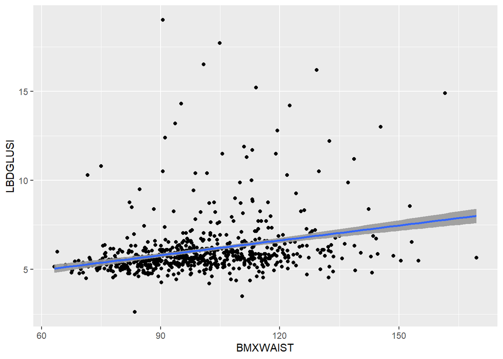

```r
ggplot(data = nhanesf, aes(BMXWAIST, LBDGLUSI)) + geom_point() + geom_smooth(method = lm, se = TRUE, alpha = 0.9)
```

Adding the prediction intervals to the scatterplot requires a little more work. You can see the intervals are *much* wider.

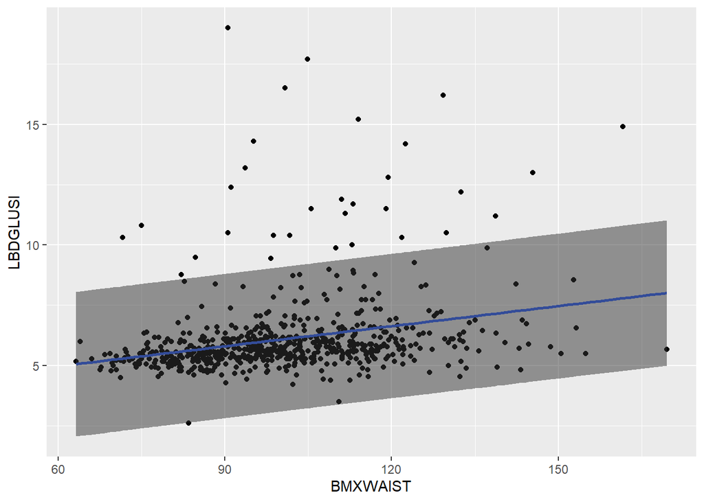

```r
# Generate predictions with prediction intervals
pred <- predict(fit1, newdata = nhanesf, interval = "prediction")

# Combine with original data
nhanesf <- cbind(nhanesf, pred)

ggplot(data = nhanesf, aes(BMXWAIST, LBDGLUSI)) + geom_point() + geom_smooth(method = lm, se = FALSE) + geom_ribbon(aes(ymin = lwr, ymax = upr), alpha = 0.5)
```

# ANOVA Table

The `anova()` function outputs the ANOVA table that summarizes the sums of squares and provides the results from the global F test.

```r
anova_fit1 = anova(fit1)
anova_fit1
```

```
## Analysis of Variance Table
##
## Response: LBDGLUSI
##            Df  Sum Sq Mean Sq F value    Pr(>F)
## BMXWAIST    1  213.36 213.361  91.932 < 2.2e-16 ***
## Residuals 963 2234.99   2.321
## ---
## Signif. codes:  0 '***' 0.001 '**' 0.01 '*' 0.05 '.' 0.1 ' ' 1
```

## The $R^2$ Statistic

The $R^2$ statistic can also be derived from the ANOVA table as it is the sum of squares of the model divided by the total sum of squares. You can see that this is the same value as from the `lm` output.

```r
r2_anova = anova_fit1$`Sum Sq`[1] / sum(anova_fit1$`Sum Sq`)

r2_lm = summary(fit1)$r.squared

r2_anova
```

```
## [1] 0.08714479
```

```r
r2_lm
```

```
## [1] 0.08714479
```

# Equivalent Tests

The t-test from the `lm` function and the Global F-test (found both in the `lm` function and the `anova` function) are equivalent. The t-test statistic should be the square root of the F statistic.

```r
# F statistic from ANOVA
anova_fit1$`F value`[1]
```

```
## [1] 91.93181
```

```r
# F statistic from lm
summary(fit1)$fstatistic[1]
```

```
##    value
## 91.93181
```

```r
# t statistic from lm squared
summary(fit1)$coef["BMXWAIST", "t value"]^2
```

```
## [1] 91.93181
```

# Residuals

There are several different types of residuals:

- Unstandardized Residuals: Raw difference between the observed and fitted values (use `residuals()`, `resid()`, or `fit1$residuals`)
- Standardized Residuals: divided by an estimate of their standard deviation (use `rstandard()`)
- Studentized Residuals: divided by the standard deviation estimated from the regression with that case removed (use`rstudent()`)

```r
# compare the three types of residuals

# compare average / quantiles
residuals_fit1 = data.frame(
  unstandardized_resid = residuals(fit1),
  standardized_resid = rstandard(fit1),
  studentized_resid = rstudent(fit1)
)
summary(residuals_fit1)
```

```
##  unstandardized_resid standardized_resid  studentized_resid
##  Min.   :-3.0122      Min.   :-1.979271   Min.   :-1.982280
##  1st Qu.:-0.6853      1st Qu.:-0.450091   1st Qu.:-0.449905
##  Median :-0.2797      Median :-0.183687   Median :-0.183595
##  Mean   : 0.0000      Mean   :-0.000009   Mean   : 0.001991
##  3rd Qu.: 0.1682      3rd Qu.: 0.110487   3rd Qu.: 0.110430
##  Max.   :13.1835      Max.   : 8.659830   Max.   : 9.013400
```

```r
# compare standard deviations
apply(residuals_fit1, 2, sd)
```

```
## unstandardized_resid   standardized_resid    studentized_resid
##             1.522648             1.000800             1.012566
```

# Testing Assumptions / Diagnostics

You should check all assumptions made to for the simple linear model and investigate any potential outliers or influential points.

Assumptions of the Linear Model:

- Independence (checked by thinking about how the data were collected)
- Normality
- Linearity
- Constant Variance

## Testing the Normality Assumption

It is recommended to test this assumption visually using QQ plots and histograms of the residuals.

### Q-Q Plot of Residuals

The closer the points are to the black line, the better the normality assumption is met.

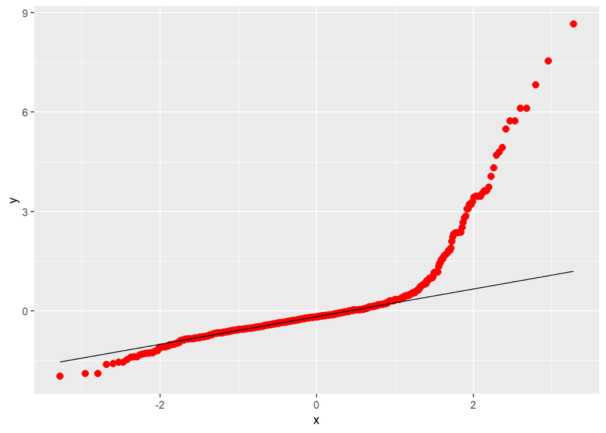

```r
ggplot(residuals_fit1, aes(sample = standardized_resid)) +
  stat_qq(size = 2.5, color = 'red') +
  stat_qq_line()
```

### Histogram of Residuals

In the histogram below, the red solid line provides a smoothed estimate of the distribution of the observed residuals. The blue dashed line is the best fit normal curve based on the mean and standard deviation of the residuals. The closer these two curves are to each other, the better the normality assumption is met.

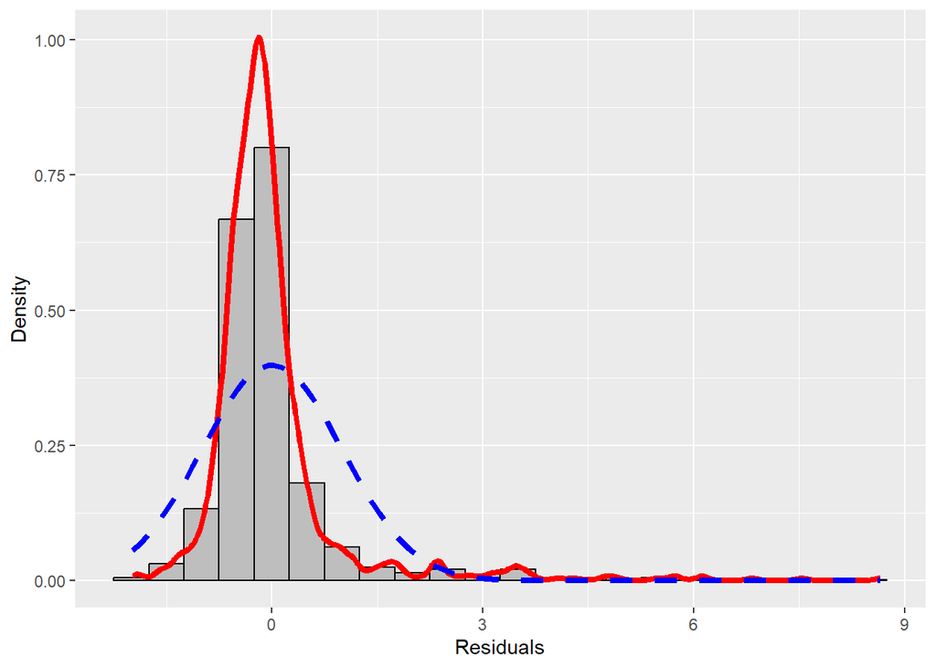

```r
# Create the histogram with the empirical density and normal curve
ggplot(residuals_fit1, aes(x = standardized_resid)) +
  geom_histogram(aes(y = ..density..), binwidth = 0.5,
                 fill = "grey", color = "black") +
  geom_density(color = "red", size = 1.5) +
  stat_function(fun = dnorm,
                args = list(mean = mean(residuals_fit1$standardized_resid, na.rm = TRUE),
                            sd = sd(residuals_fit1$standardized_resid, na.rm = TRUE)),
                color = "blue", linetype = "dashed", size = 1.5) +
  labs(x = "Residuals", y = "Density")
```

## Testing the Linearity Assumption

You can check this assumption by plotting a component-plus-residual (CR) plot (partial residual plot). This can be done in R using `crPlots()` in the `car` package.

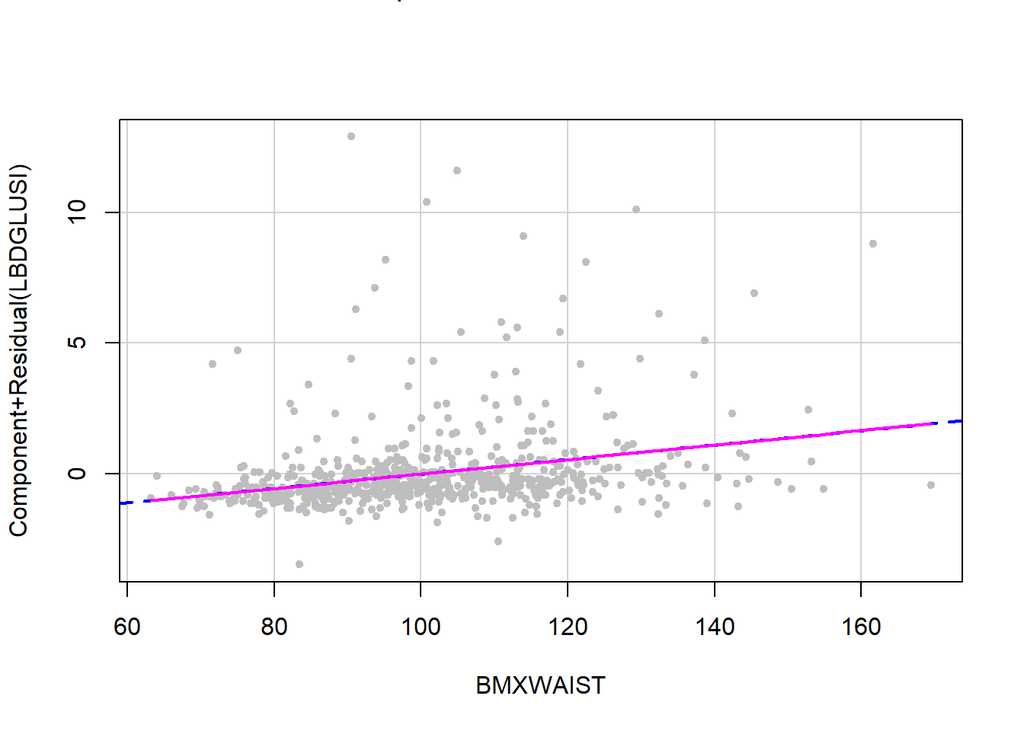

```r
crPlots(fit1, pch=20, col="gray",
        smooth = list(smoother= gamLine))
```

## Testing the Constant Variance Assumption

You can plot the residuals vs the fitted values to see if the spread of residuals varies across the fitted values. This can be done in R using the `residualPlots()` function in the `car` package.

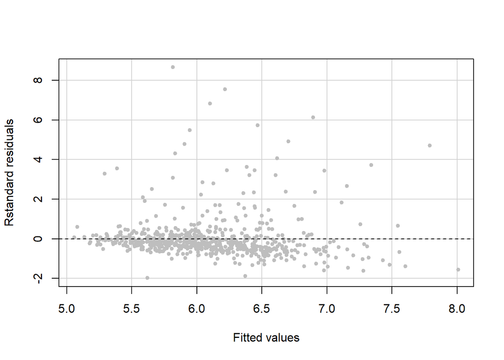

```r
# fitted = T requests the residual vs. fitted plot
# tests = F and quadratic = F suppresses hypothesis tests
residualPlots(fit1,
              pch=20, col="gray", type = "rstandard", terms = ~ 1,
              fitted = T, tests = F, quadratic = F)
```

## Outliers

An outlier in simple linear regression is an observation with a very large residual. This can be evaluated by looking at the studentized residuals vs the fitted values. In R, this can be also be done using the `residualPlots()` function and changing the residual type.

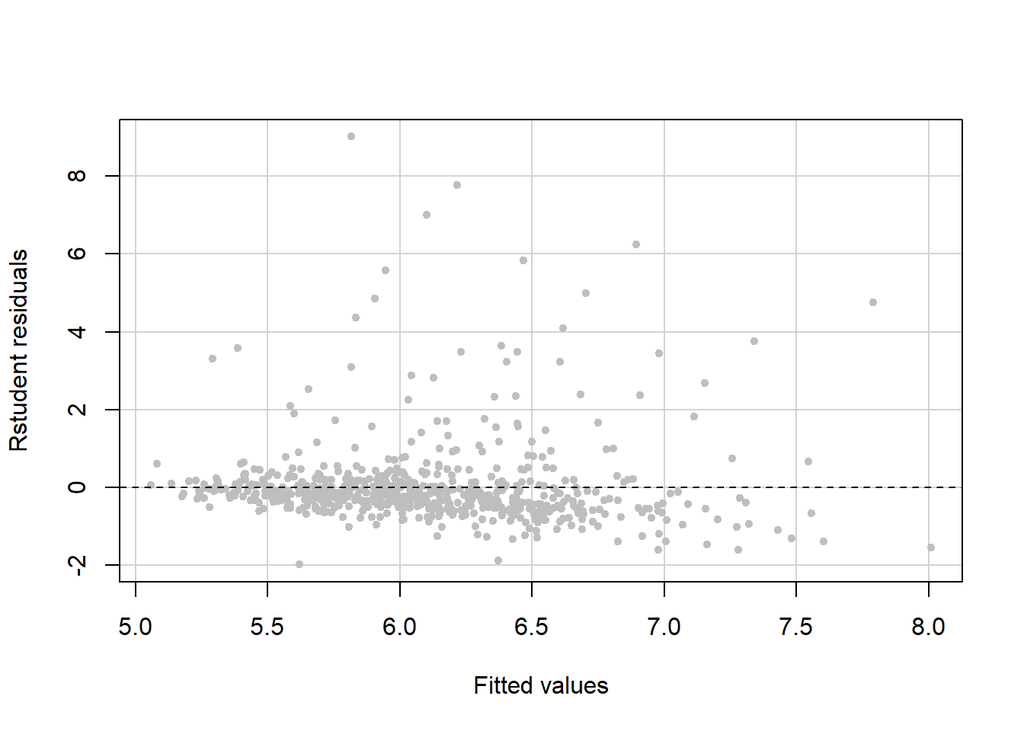

```r
residualPlots(fit1,
              pch=20, col="gray", type = "rstudent", terms = ~ 1,
              fitted = T, tests = F, quadratic = F)
```

You can also use an statistical test for outliers using the `outlierTest()` function, which flags observations with unusually large studentized residuals.

```r
outlierTest(fit1, n.max = Inf)
```

```
##        rstudent unadjusted p-value Bonferroni p
## 207    9.013400         1.0556e-18   1.0186e-15
## 1495   7.771324         1.9887e-14   1.9191e-11
## 2061   6.996552         4.9108e-12   4.7389e-09
## 1659   6.240591         6.5257e-10   6.2973e-07
## 1659.1 6.240591         6.5257e-10   6.2973e-07
## 1294   5.833604         7.4046e-09   7.1455e-06
## 1294.1 5.833604         7.4046e-09   7.1455e-06
## 2175   5.571030         3.2867e-08   3.1717e-05
## 1648   4.987459         7.2562e-07   7.0023e-04
## 1842   4.846802         1.4621e-06   1.4109e-03
## 705    4.753567         2.3037e-06   2.2231e-03
## 1506   4.353488         1.4833e-05   1.4314e-02
## 250    4.095267         4.5714e-05   4.4114e-02
```

## Leverage Points

Leverage points are data points with unusual predictor values compared to the rest of the data. Leverage values can be calculated using the `hatvalues()` function.

```r
hatvalues(fit1) %>% sort(decreasing = TRUE)
```

[output not shown]

[output cut: 267 more lines]

```
## 0.001041688 0.001040446 0.001040063 0.001040063 0.001039705 0.001039705
##       677.1         791       791.1         960       960.1        1633
## 0.001039705 0.001039359 0.001039359 0.001039036 0.001039036 0.001038727
##        1637         377       377.1      1637.1         739         586
## 0.001038167 0.001038167 0.001038167 0.001038167 0.001037916 0.001037679
##         519       519.1        1320        1811        1848         426
## 0.001037679 0.001037679 0.001037465 0.001037465 0.001037085 0.001037085
##        1249        2067      2067.1        1273        2185        1418
## 0.001037085 0.001036921 0.001036921 0.001036778 0.001036778 0.001036650
##        1092         533        2061        1035      1035.1       533.1
## 0.001036650 0.001036650 0.001036650 0.001036650 0.001036650 0.001036650
##       533.2        1915        1172      1172.1         355       355.1
## 0.001036650 0.001036543 0.001036543 0.001036543 0.001036326 0.001036326
##         352       355.2        1381        2014         587
## 0.001036326 0.001036326 0.001036326 0.001036290 0.001036272
```

## Influential Observations

Influential observations are ones that alter the regression coefficients by a significant amount when they are included in the model. To test the influence of a point, you can compare the regression coefficient estimates including the point to the ones without including the point in the sample.

Cook’s distance (`cooks.distance()`) is a measure that takes into account the difference in all coefficient estimates when fitting the model with and without the observation in question. Standardized DFBetas (`dfbetas()`) measure the difference for each coefficient estimate separately. The `influenceIndexPlot()` function in the `car` package can plot the Cook’s distance, and the `ols_plot_dfbetas()` function in the `olsrr` package can plot the DFBetas.

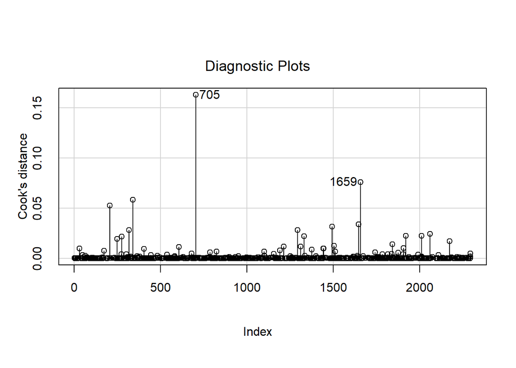

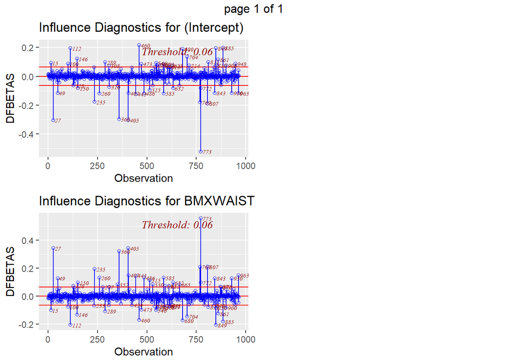

```r
influenceIndexPlot(fit1, vars = "Cook")

ols_plot_dfbetas(fit1)
```

## Functional Form

For the NHANES example, we saw when checking the assumptions that the linearity assumption was not violated. In order to explore other functional forms of the predictor, we will use a different example, from the UNHDD dataset. We want to quantify the effect of female education on adult female mortality.

First let’s fit a simple linear regression model and check the linearity assumption.

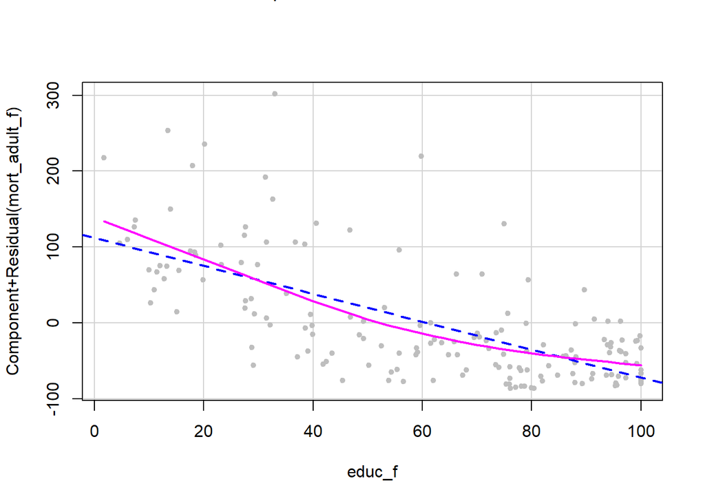

```r
# fit the model
fit2 = lm(mort_adult_f ~ educ_f, data = unhdd)

# check linearity assumption
crPlots(fit2, pch=20, col="gray",
        smooth = list(smoother= gamLine))
```

We can see from the plot that the solid pink line looks more quadratic and doesn’t quite overlap with the linear one. We will try fitting a model with a quadratic term next. To do so, you must use the syntax `I(educ_f^2)` in addition to the linear term.

```r
# fit quadratic model
fit2_quadratic = lm(mort_adult_f ~ educ_f + I(educ_f^2),
                    data = unhdd)
summary(fit2_quadratic)
```

```
##
## Call:
## lm(formula = mort_adult_f ~ educ_f + I(educ_f^2), data = unhdd)
##
## Residuals:
##     Min      1Q  Median      3Q     Max
## -111.06  -32.31  -15.95   18.46  257.32
##
## Coefficients:
##              Estimate Std. Error t value Pr(>|t|)
## (Intercept) 274.61772   17.63850  15.569  < 2e-16 ***
## educ_f       -4.06506    0.72054  -5.642 7.53e-08 ***
## I(educ_f^2)   0.01991    0.00629   3.166  0.00185 **
## ---
## Signif. codes:  0 '***' 0.001 '**' 0.01 '*' 0.05 '.' 0.1 ' ' 1
##
## Residual standard error: 57.74 on 159 degrees of freedom
##   (27 observations deleted due to missingness)
## Multiple R-squared:  0.4846, Adjusted R-squared:  0.4781
## F-statistic: 74.76 on 2 and 159 DF,  p-value: < 2.2e-16
```

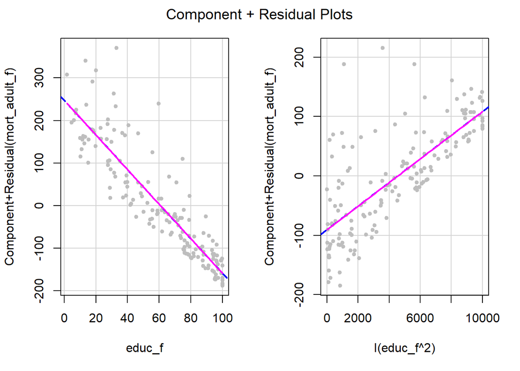

```r
# re-check linearity assumption
crPlots(fit2_quadratic, pch=20, col="gray",
        smooth = list(smoother= gamLine))
```